# Introduction to rGeoDa

lixun910

6/6/2019

```css
.rCode {
background-color: #D7ECE8;
}
```

## Install rgeoda for R

For testing stage, the easiest way to install the development version of rgeoda is using `devtools`. If you don’t have devtools installed, use the following line:

```
install.packages("devtools")
```

Then, you can call `install_github()` function to install `rgeoda` from the source code:

```r
library(devtools)
install_github('lixun910/rgeoda')
```

If everything installed without error, you should be able to load `rgeoda`:

```r
library(rgeoda)
```

## Load Geospatial Data

In this note, we will use an ESRI Shapefile `natregimes.shp` comes with the package:

```r
nat_path <- system.file("extdata", "natregimes.shp", package = "rgeoda")
```

Use the path above (or the path to your own dataset), we can create a GeoDa instance, and the GeoDa instance is the main entry point of rgeoda.

```r
gda <- GeoDa(nat_path)
```

rGeoDa provides some functions to check the meta data of the loaded dataset:

```r
num_obs <- gda$GetNumObs()
num_cols <- gda$GetNumCols()
field_types <- gda$GetFieldTypes()
field_names <- gda$GetFieldNames()
```

## Access Table Data

One can call function `GetNumericCol(string col_name)` to get numeric data (vector type) from GeoDa instance. For example, to get data of column “HR60”:

```r
hr60 <- gda$GetNumericCol("HR60")
```

## Spatial Weights

One can call function `CreateContiguityWeights(string poly_id="", bool is_queen=true, int order=1, bool include_lower_order=false)` to create a Queen or Rook contiguity weights:

```r
queen_w <- gda$CreateContiguityWeights(is_queen=TRUE)
```

To access the properties of the created weights object, one can just access the attributes of the returned weights object `queen_w`:

```r
cat("weight_type: ", queen_w$weight_type,
    "\nis_symmetric: ", queen_w$is_symmetric,
    "\nsparsity:",queen_w$sparsity,
    "\ndensity:",queen_w$density,
    "\nmin_nbrs:",queen_w$min_nbrs,
    "\nmax_nbrs:",queen_w$max_nbrs,
    "\nmean_nbrs:",queen_w$mean_nbrs,
    "\nmedian_nbrs:",queen_w$median_nbrs, "\n")
```

```
## weight_type:  gal_type
## is_symmetric:  TRUE
## sparsity: 0
## density: 0.190896
## min_nbrs: 1
## max_nbrs: 14
## mean_nbrs: 5.889141
## median_nbrs: 6
```

To save the weights file to local disk, one can call the function of weights object `SaveToFile(string file_path)`

## Spatial Data Analysis

### Local Spatial Autocorrelation

Using the created Queen weights `queen_w` and the data `hr60`, we can call function `LISA(GeoDaWeight w, vector data)` to compute the local spatial autocorrelation of variable “HR60”.

```r
lisa <- gda$LISA(queen_w, hr60)
```

We can access the LISA results by calling the “getter” methods from the returned LISA object:

```r
lags <- lisa$GetLagValues()
lags[1:20]
```

```
##  [1] -0.6293091 -0.3530115 -0.5508477 -0.4217541 -0.5088273 -0.2004406
##  [7] -0.4434569  0.4960453  0.2903570  0.9109106  0.3326043 -0.2865061
## [13] -0.5457504 -0.7972207 -0.5379562 -0.5026332 -0.6643260 -0.6234103
## [19] -0.6721546 -0.7972207
```

Get local moran values:

```r
lms <- lisa$GetLocalMoranValues()
lms[1:20]
```

```
##  [1]  0.50169822  0.28142804  0.25742058  0.14121956  0.40564765
##  [6]  0.15979543 -0.27254825 -0.30667660  0.36103503 -0.72619680
## [11] -0.26515906  0.04716326  0.43508356  0.63556087  0.42886986
## [16]  0.40070958  0.18321405  0.49699558  0.53585554  0.63556087
```

Get pseudo-p values:

```r
pvals <- lisa$GetLocalSignificanceValues()
pvals[1:20]
```

```
##  [1] 0.090 0.302 0.099 0.088 0.120 0.397 0.187 0.073 0.264 0.068 0.216
## [12] 0.338 0.115 0.029 0.062 0.114 0.037 0.096 0.027 0.013
```

Get LISA category values:

```r
cats <- lisa$GetClusterIndicators()
cats[1:20]
```

```
##  [1] 0 0 0 0 0 0 0 0 0 0 0 0 0 2 0 0 2 0 2 2
```

You can easily re-run the LISA computation by calling its `Run()` function. For example, re-run the above LISA exampe using 9999 permutations:

```r
lisa$SetNumPermutations(9999)
```

```r
lisa$Run()
```

Display the p-values after 9999 permutations:

```r
pvals <- lisa$GetLocalSignificanceValues()
pvals[1:20]
```

```
##  [1] 0.0874 0.2911 0.0942 0.1024 0.1149 0.4212 0.1698 0.0735 0.2430 0.0660
## [11] 0.2079 0.3471 0.1012 0.0250 0.0739 0.1256 0.0353 0.0902 0.0180 0.0075
```

Since rgeoda is using GeoDa’s C++ code, by default, rgeoda uses multi-threading to accelerate the computation of Local Moran. One can also specify how many threads to run the computation:

```r
lisa$SetNumThreads(4)
```

```r
lisa$Run()
```

Display the p-values after re-run LISA with 4 threads:

```r
pvals <- lisa$GetLocalSignificanceValues()
pvals[1:20]
```

```
##  [1] 0.0874 0.2911 0.0942 0.1024 0.1149 0.4212 0.1698 0.0735 0.2430 0.0660
## [11] 0.2079 0.3471 0.1012 0.0250 0.0739 0.1256 0.0353 0.0902 0.0180 0.0075
```

## Clustering

### SKATER

Using the function `SKATER(int k, GeoDaWeight w, Vector column_names, String distance_method='euclidean')` to run a spatially constrained clustering on current dataset.

```r
skater <- gda$SKATER(10, queen_w, c("HR60", "PO60"))
skater
```

```
##    [1]  1  1  1  1  1  1  1  1  1  1  1  1  1  1  1  1  1  1  1  1  1  1  1
##   [24]  1  1  1  1  1  1  1  1  1  1  1  1  1  1  1  1  1  1  1  1  1  1  1
##   [47]  1  1  1  1  1  1  1  1  1  1  1  1  1  1  1  1  1  1  1  1  1  1  1
##   [70]  1  1  1  1  1  1  1  1  1  1  1  1  1  1  1  1  1  1  1  1  1  1  1
##   [93]  1  1  1  1  1  1  1  1  1  1  1  1  1  1  1  1  1  1  1  1  1  1  1
##  [116]  1  1  1  1  1  1  1  1  1  1  1  1  1  1  1  1  1  1  1  1  1  1  1
##  [139]  1  1  1  1  1  1  1  1  1  1  1  1  1  1  1  1  1  1  1  1  1  1  1
##  [162]  1  1  1  1  1  1  1  1  1  1  1  1  1  1  1  1  1  1  1  1  1  1  1
##  [185]  1  1  1  1  1  1  1  1  1  1  1  1  1  1  1  1  1  1  1  1  1  1  1
##  [208]  1  1  1  1  1  1  1  1  1  1  1  1  1  1  1  1  1  1  1  1  1  1  1
##  [231]  1  1  1  1  1  1  1  1  1  1  1  1  1  1  1  1  1  1  1  1  1  1  1
##  [254]  1  1  1  1  1  1  1  1  1  1  1  1  1  1  1  1  1  1  1  1  1  1  1
##  [277]  1  1  1  1  1  1  1  1  1  1  1  1  1  1  1  1  1  1  1  1  1  1  1
##  [300]  1  1  1  1  1  1  1  1  1  1  1  1  1  1  1  1  1  1  1  1  1  1  1
##  [323]  1  1  1  1  1  1  1  1  1  1  1  1  1  1  1  1  1  1  1  1  1  4  1
```

[output cut: 120 more lines]

## Visualization using sp

```r
spo <- geoda_to_sp(gda)
```

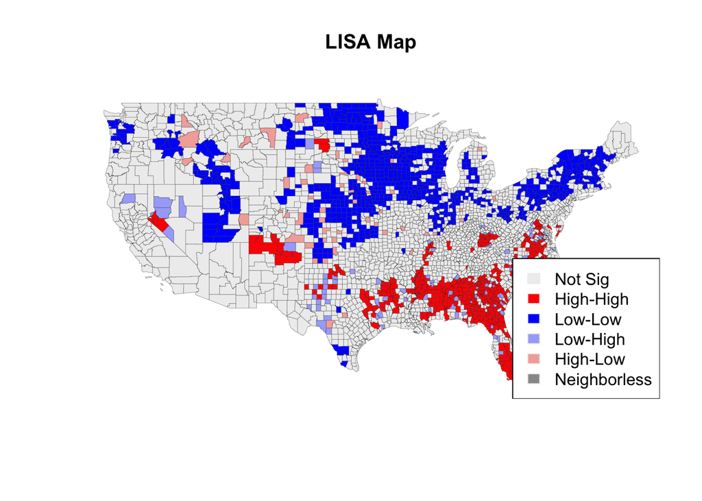

```r
colors <- sapply(cats, function(x){return(lisa_colors[[x+1]])})
plot(spo, col=colors, border = "#333333", lwd=0.2)
title(main = "LISA Map")
legend('bottomright', legend = lisa_labels,
       fill = lisa_colors, border = "#eeeeee")
```